# Labwork-Batman

Kwate Dassi Loic

12/9/2021

## Labwork: Is Batman somewhere?

## Data Loading

```r
library(ggplot2)
data = read.table(file="bats.txt", sep=";", skip=3, header=T)
names(data)
```

```
## [1] "Species" "Diet"    "Clade"   "BOW"     "BRW"     "AUD"     "MOB"
## [8] "HIP"
```

## Study of the relationship between brain weight and body mass

- Scatter plot of the function $BRW = f(BOW)$

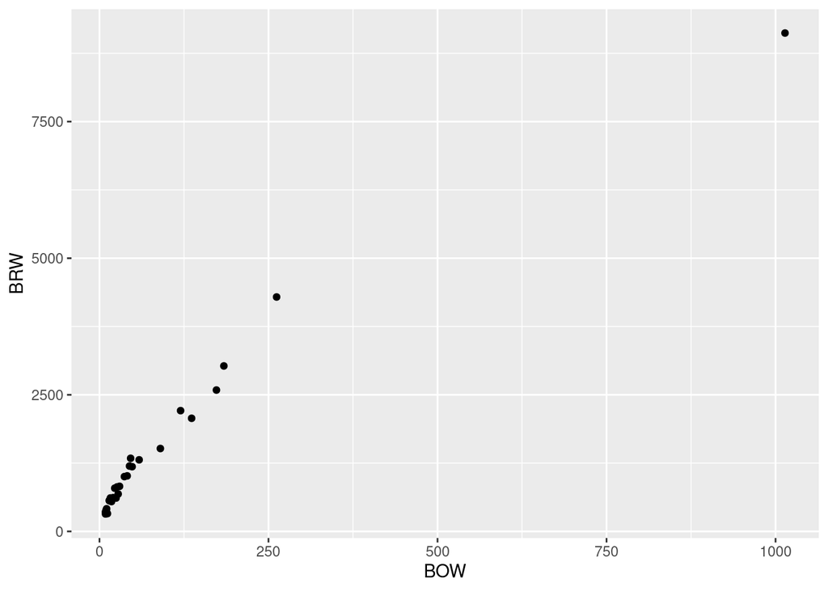

```r
phyto = data[(data$Diet == 1),]
ggplot(phyto, aes(x=BOW, y=BRW)) +
  geom_point()
```

- Approximate the function $BRW = f(BOW)$ with a simple linear regression. That is, the approximated function will be the following:
  $$BRW = \beta_0 + \beta_1 \times BOW$$

```r
reg1 = lm(BRW ~ BOW, data=phyto)
summary(reg1)
```

```
##
## Call:
## lm(formula = BRW ~ BOW, data = phyto)
##
## Residuals:
##     Min      1Q  Median      3Q     Max
## -628.32 -233.94  -65.74  158.26 1308.59
##
## Coefficients:
##             Estimate Std. Error t value Pr(>|t|)
## (Intercept) 623.4469    81.4762   7.652 3.14e-08 ***
## BOW           8.9999     0.3972  22.659  < 2e-16 ***
## ---
## Signif. codes:  0 '***' 0.001 '**' 0.01 '*' 0.05 '.' 0.1 ' ' 1
##
## Residual standard error: 396.9 on 27 degrees of freedom
## Multiple R-squared:   0.95,  Adjusted R-squared:  0.9482
## F-statistic: 513.4 on 1 and 27 DF,  p-value: < 2.2e-16
```

## Interpretation of the first linear regression

- Value of the intercept term: $623.449$
- The $p-values$ of the statistic test are the following: $2.2\times 10^{-16}$ and $3.14 \times 10 ^ {-8}$
- Hypothesis $H_0$ of the test: $\beta_0 = 0$ and $\beta_1 = 0$
- Both the $p-values$ are below the common threshold which is $5\%$ therefore with can reject the null hypothesis
- Regarding the value of the adjusted R-squared, $0.9482$, which is above the $0.8$, we can said that the simple linear regression is expressive and enough to approximate the true mapping between the body mass and brain mass

### Analysis of variance of the simple linear regression

```r
anova(reg1)
```

```
## Analysis of Variance Table
##
## Response: BRW
##           Df   Sum Sq  Mean Sq F value    Pr(>F)
## BOW        1 80888380 80888380  513.42 < 2.2e-16 ***
## Residuals 27  4253838   157550
## ---
## Signif. codes:  0 '***' 0.001 '**' 0.01 '*' 0.05 '.' 0.1 ' ' 1
```

The analysis of variance provide supplementary information on variance, namely, the total sum of squares and the mean of the sum of squares.

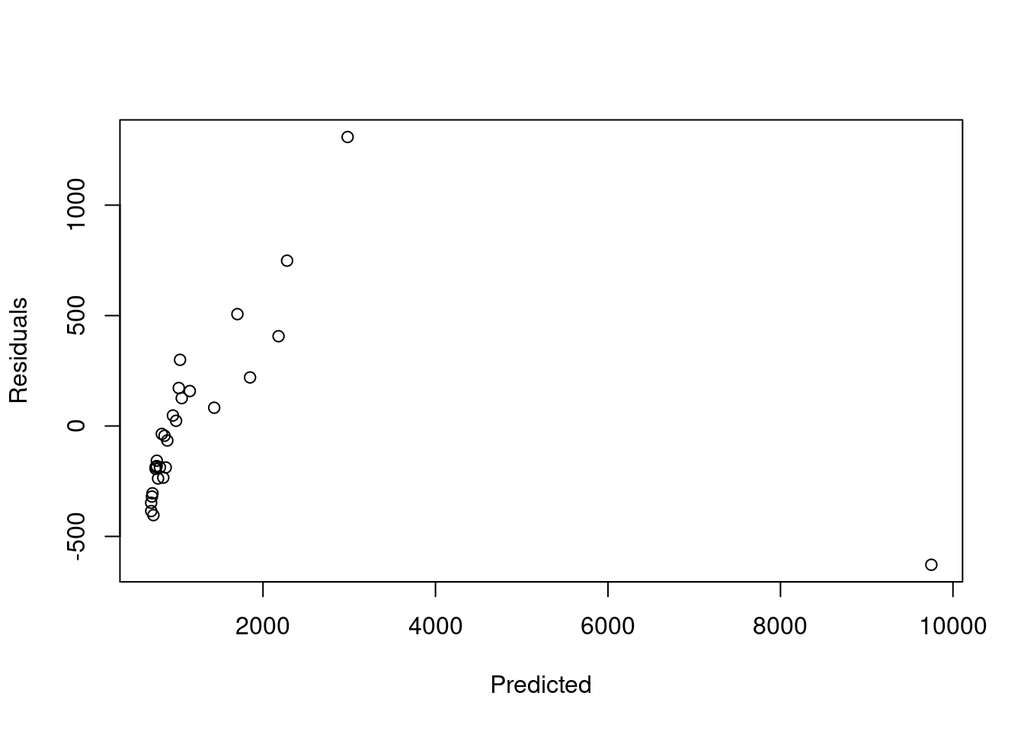

```r
plot(reg1$fitted.values, reg1$residuals, xlab="Predicted", ylab="Residuals")
```

Based on the trend obtained from this previous plot, we can say that the residuals tend to increase for larger fitted values.

### Regression without larger fitted values

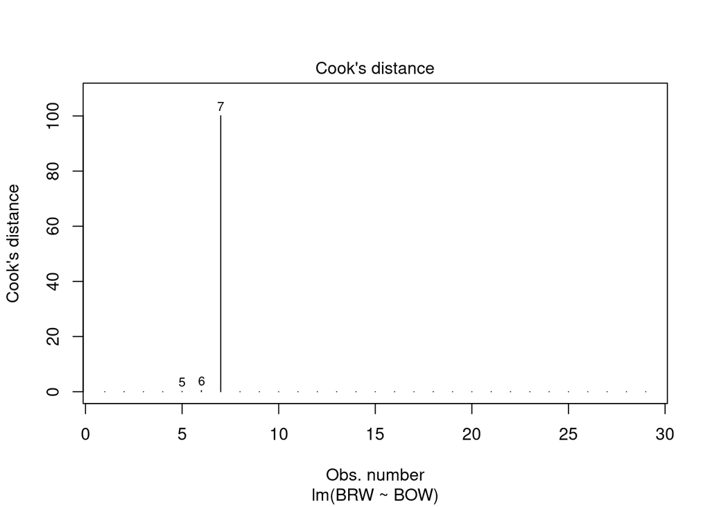

```r
plot(reg1, 4)
```

```r
which(phyto$BRW > 8000)
```

```
## [1] 7
```

```r
phytobis = phyto[which(phyto$BRW < 8000),]

reg2 = lm(BRW ~ BOW, data=phytobis)
summary(reg2)
```

```
##
## Call:
## lm(formula = BRW ~ BOW, data = phytobis)
##
## Residuals:
##     Min      1Q  Median      3Q     Max
## -269.76  -93.33    8.73  112.93  322.55
##
## Coefficients:
##             Estimate Std. Error t value Pr(>|t|)
## (Intercept) 346.5452    35.4920   9.764 3.48e-10 ***
## BOW          14.5099     0.4285  33.860  < 2e-16 ***
## ---
## Signif. codes:  0 '***' 0.001 '**' 0.01 '*' 0.05 '.' 0.1 ' ' 1
##
## Residual standard error: 141.8 on 26 degrees of freedom
## Multiple R-squared:  0.9778, Adjusted R-squared:  0.977
## F-statistic:  1147 on 1 and 26 DF,  p-value: < 2.2e-16
```

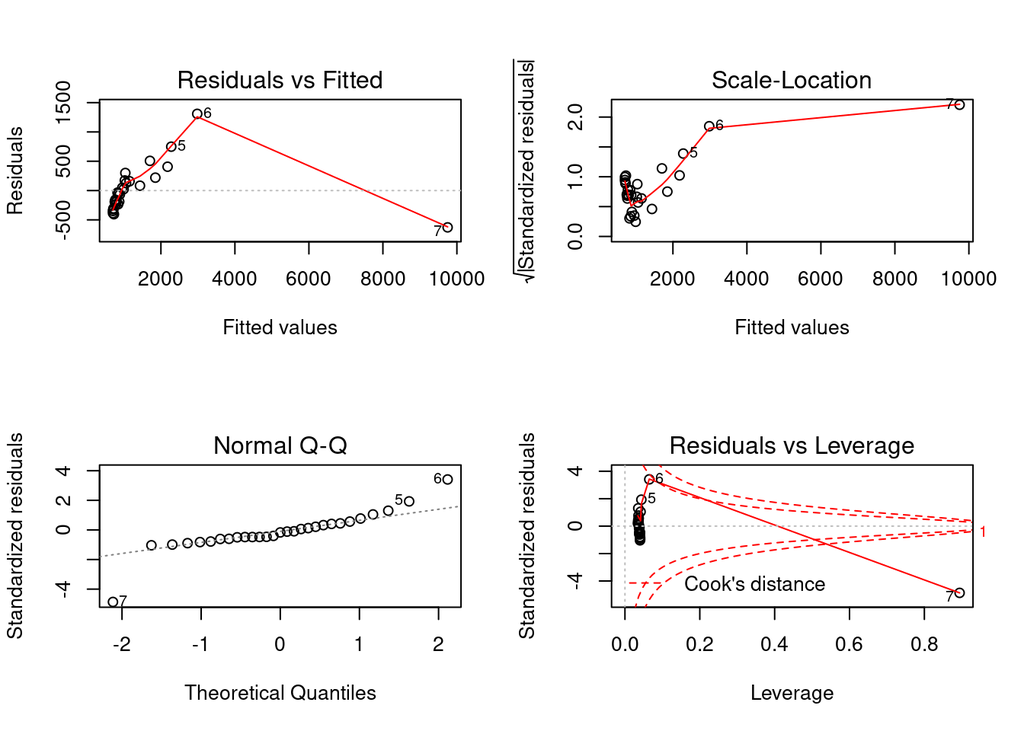

```r
par(mfcol=c(2, 2))
plot(reg1)
```

# Study of the contribution to the total weight of each part of the brain

## Correlation analysis between explicative variables

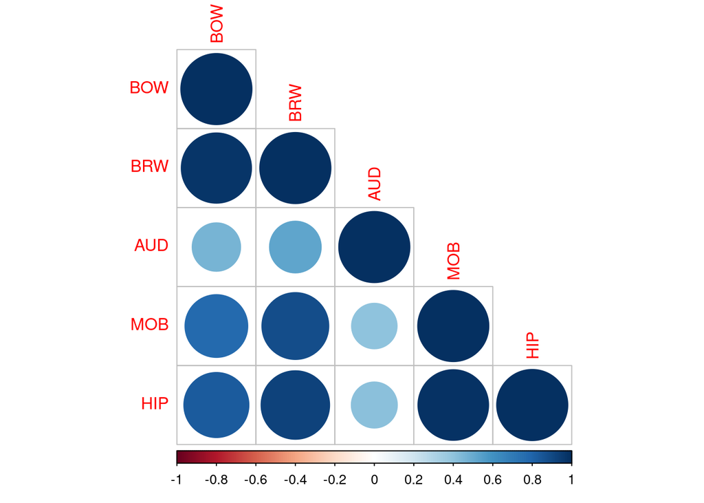

```r
library(corrplot)
phytoNum = phyto[, c(4:8)]
mat.cor = cor(phytoNum)
corrplot(mat.cor, type="lower")
```

```r
cor.test(phyto$BRW, phyto$HIP)
```

```
##
##  Pearson's product-moment correlation
##
## data:  phyto$BRW and phyto$HIP
## t = 12.91, df = 27, p-value = 4.574e-13
## alternative hypothesis: true correlation is not equal to 0
## 95 percent confidence interval:
##  0.8502663 0.9658107
## sample estimates:
##       cor
## 0.9276811
```

```r
cor.test(phyto$BRW, phyto$MOB)
```

```
##
##  Pearson's product-moment correlation
##
## data:  phyto$BRW and phyto$MOB
## t = 9.7964, df = 27, p-value = 2.203e-10
## alternative hypothesis: true correlation is not equal to 0
## 95 percent confidence interval:
##  0.7644185 0.9442114
## sample estimates:
##       cor
## 0.8834215
```

```r
cor.test(phyto$BRW, phyto$AUD)
```

```
##
##  Pearson's product-moment correlation
##
## data:  phyto$BRW and phyto$AUD
## t = 3.2338, df = 27, p-value = 0.003215
## alternative hypothesis: true correlation is not equal to 0
## 95 percent confidence interval:
##  0.2007495 0.7497021
## sample estimates:
##       cor
## 0.5283792
```

```r
regm = lm(BRW ~ AUD + MOB + HIP, data=phytobis)
summary(regm)
```

```
##
## Call:
## lm(formula = BRW ~ AUD + MOB + HIP, data = phytobis)
##
## Residuals:
##     Min      1Q  Median      3Q     Max
## -268.55  -68.84    9.88   61.66  375.34
##
## Coefficients:
##             Estimate Std. Error t value Pr(>|t|)
## (Intercept) -312.692     76.628  -4.081  0.00043 ***
## AUD           47.989      6.067   7.910 3.85e-08 ***
## MOB           -2.444      3.257  -0.750  0.46034
## HIP           15.981      2.960   5.399 1.52e-05 ***
## ---
## Signif. codes:  0 '***' 0.001 '**' 0.01 '*' 0.05 '.' 0.1 ' ' 1
##
## Residual standard error: 158.5 on 24 degrees of freedom
## Multiple R-squared:  0.9744, Adjusted R-squared:  0.9712
## F-statistic: 304.5 on 3 and 24 DF,  p-value: < 2.2e-16
```

```r
anova(regm)
```

```
## Analysis of Variance Table
##
## Response: BRW
##           Df   Sum Sq  Mean Sq F value    Pr(>F)
## AUD        1  6817133  6817133 271.210 1.397e-14 ***
## MOB        1 15409397 15409397 613.040 < 2.2e-16 ***
## HIP        1   732653   732653  29.148 1.519e-05 ***
## Residuals 24   603265    25136
## ---
## Signif. codes:  0 '***' 0.001 '**' 0.01 '*' 0.05 '.' 0.1 ' ' 1
```